# Chulwalar Case Study

#### the optimisation, the forecast is very similar to the ses() model.

```r
Model_holt_2<- holt(BlueEtelAsIs, exponential=TRUE,h=12)
summary(Model_holt_2)
```

```
##
## Forecast method: Holt's method with exponential trend
##
## Model Information:
## Holt's method with exponential trend
##
## Call:
##  holt(x = BlueEtelAsIs, h = 12, exponential = TRUE)
##
##   Smoothing parameters:
##     alpha = 0.8233
##     beta  = 0.0001
##
##   Initial states:
##     l = 344616.7087
##     b = 0.9822
##
##   sigma:  0.287
##
##      AIC     AICc      BIC
## 1946.718 1947.315 1955.824
##
## Error measures:
##                    ME     RMSE      MAE        MPE     MAPE   MASE
## Training set 6767.601 71076.53 53495.88 -0.9592992 17.56174 1.3878
##                   ACF1
## Training set 0.0174015
##
## Forecasts:
##          Point Forecast     Lo 80    Hi 80     Lo 95     Hi 95
## Jan 2014       355234.5 223263.12 487965.3 151969.25  556459.9
## Feb 2014       349026.0 188833.52 521956.7 127666.12  641937.9
## Mar 2014       342925.9 163713.43 558029.3 104256.22  708384.2
## Apr 2014       336932.5 142251.36 576790.4  88663.97  765232.4
## May 2014       331043.9 126601.12 588589.6  76451.62  811420.3
## Jun 2014       325258.1 112750.42 607722.0  68162.73  873045.2
## Jul 2014       319573.5 103027.39 611240.7  58404.85  941671.1
## Aug 2014       313988.2  90464.37 619126.0  52446.97  939321.1
## Sep 2014       308500.6  81960.44 631905.5  45787.54  991707.7
## Oct 2014       303108.8  74911.60 641678.9  39660.85 1031812.0
## Nov 2014       297811.3  66314.66 629773.7  33561.78 1063267.7
## Dec 2014       292606.4  59605.16 633079.9  30555.57 1119888.7
```

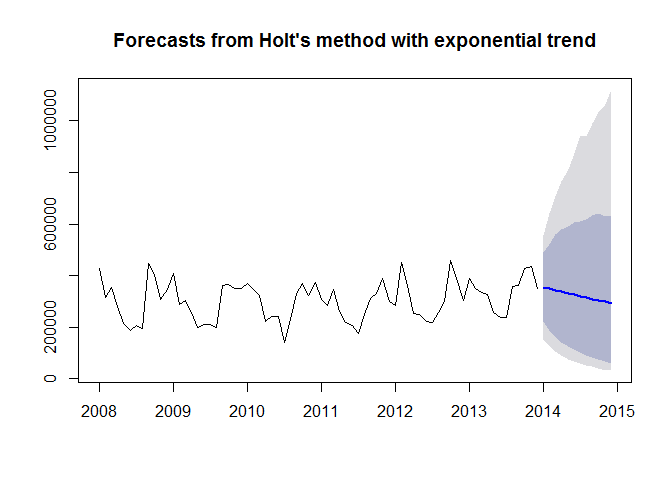

```r
plot(Model_holt_2)
```

#### As such simple trends tend to forecast the future to positively, we have added a dampener. #### Similar values to that of Model_holt_1

```r
Model_holt_3 <- holt(BlueEtelAsIs, damped=TRUE,h=12)
summary(Model_holt_3)
```

```
##
## Forecast method: Damped Holt's method
##
## Model Information:
## Damped Holt's method
##
## Call:
##  holt(x = BlueEtelAsIs, h = 12, damped = TRUE)
##
##   Smoothing parameters:
##     alpha = 0.8074
##     beta  = 0.0001
##     phi   = 0.9271
##
##   Initial states:
##     l = 344604.6786
##     b = -1874.3426
##
##   sigma:  71352.88
##
##      AIC     AICc      BIC
## 1927.177 1928.086 1938.560
##
## Error measures:
##                   ME     RMSE      MAE       MPE     MAPE     MASE
## Training set 747.895 71352.88 54509.17 -3.060054 18.15212 1.414087
##                    ACF1
## Training set 0.03120472
##
## Forecasts:
##          Point Forecast    Lo 80    Hi 80      Lo 95    Hi 95
## Jan 2014       364346.3 272903.9 455788.7 224497.219 504195.4
## Feb 2014       364343.7 246805.9 481881.4 184585.239 544102.1
## Mar 2014       364341.2 225526.3 503156.2 152042.054 576640.4
## Apr 2014       364338.9 207096.9 521581.0 123857.946 604819.9
## May 2014       364336.8 190608.7 538065.0  98642.557 630031.1
## Jun 2014       364334.9 175552.6 553117.1  75617.379 653052.4
## Jul 2014       364333.1 161609.6 567056.5  54294.358 674371.8
## Aug 2014       364331.4 148564.0 580098.8  34343.611 694319.1
## Sep 2014       364329.8 136261.7 592397.9  15529.796 713129.8
## Oct 2014       364328.4 124588.6 604068.1  -2321.962 730978.7
## Nov 2014       364327.0 113456.8 615197.2 -19345.817 747999.9
## Dec 2014       364325.8 102797.4 625854.2 -35647.355 764298.9
```

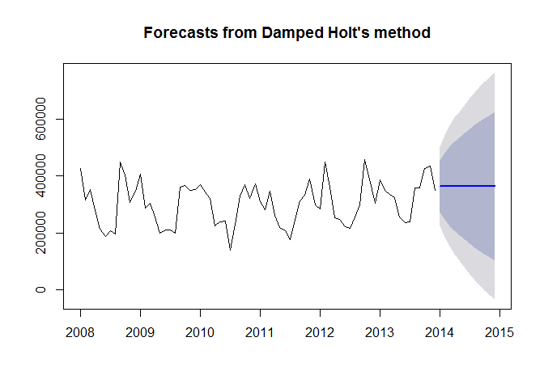

```r
plot(Model_holt_3)
```

#### This also works for exponential trends. #### The values remain worse.

```r
Model_holt_4 <- holt(BlueEtelAsIs, exponential=TRUE, damped=TRUE,h=12)
summary(Model_holt_4)
```

```
##
## Forecast method: Damped Holt's method with exponential trend
##
## Model Information:
## Damped Holt's method with exponential trend
##
## Call:
##  holt(x = BlueEtelAsIs, h = 12, damped = TRUE, exponential = TRUE)
##
##   Smoothing parameters:
##     alpha = 0.7823
##     beta  = 0.0001
##     phi   = 0.8511
##
##   Initial states:
##     l = 344616.411
##     b = 0.9384
##
##   sigma:  0.2806
##
##      AIC     AICc      BIC
## 1947.789 1948.698 1959.172
##
## Error measures:
##                    ME     RMSE      MAE       MPE     MAPE     MASE
## Training set 2372.313 71121.27 54593.82 -2.593024 18.12276 1.416283
##                    ACF1
## Training set 0.04579882
##
## Forecasts:
##          Point Forecast     Lo 80    Hi 80     Lo 95     Hi 95
## Jan 2014       366201.7 241476.27 492509.2 165272.60  557423.1
## Feb 2014       366208.4 206704.11 536980.3 141579.69  644866.2
## Mar 2014       366214.1 185049.19 570518.0 123891.24  730536.3
## Apr 2014       366219.0 168936.74 599703.2 102698.62  790471.3
## May 2014       366223.1 149617.76 625794.6  86603.83  868231.8
## Jun 2014       366226.6 137522.06 650144.2  77153.89  928743.7
## Jul 2014       366229.6 125018.68 664748.7  67608.35  983195.9
## Aug 2014       366232.2 112951.70 681661.9  63000.36 1008772.3
## Sep 2014       366234.3 106477.69 694549.7  59315.27 1098144.8
## Oct 2014       366236.2  97118.75 705364.8  52566.55 1121930.2
## Nov 2014       366237.7  91259.16 721858.3  48022.85 1154705.4
## Dec 2014       366239.1  85791.80 726788.1  44549.09 1216323.2
```

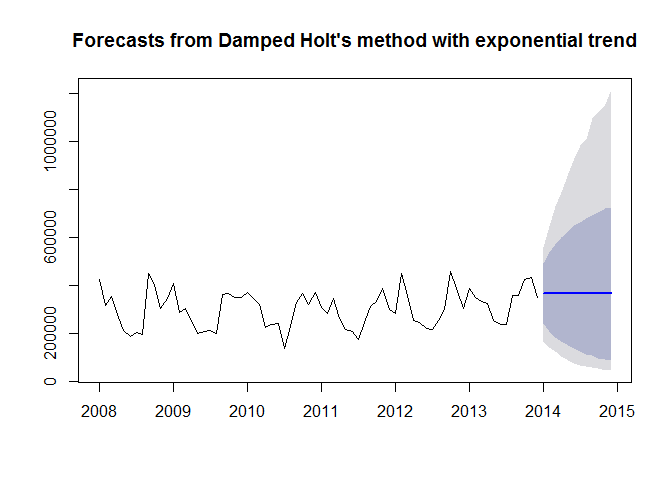

```r
plot(Model_holt_4)
```

#### level and slope can be plotted individually for each model.

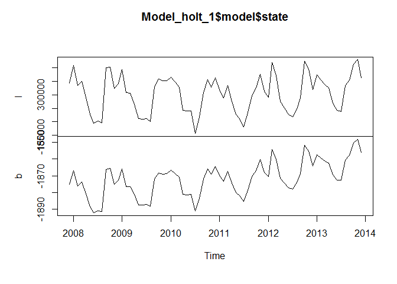

```r
plot(Model_holt_1$model$state)
```

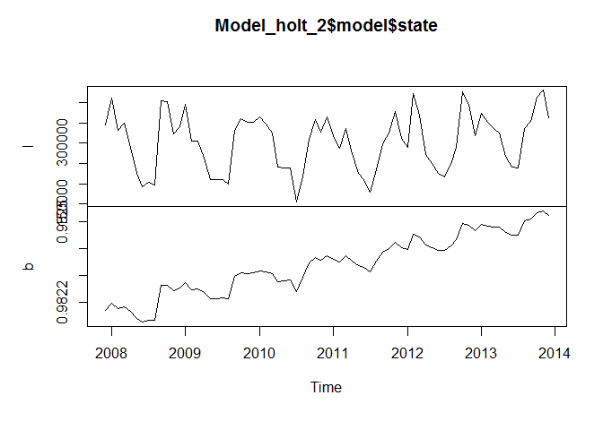

```r
plot(Model_holt_2$model$state)
```

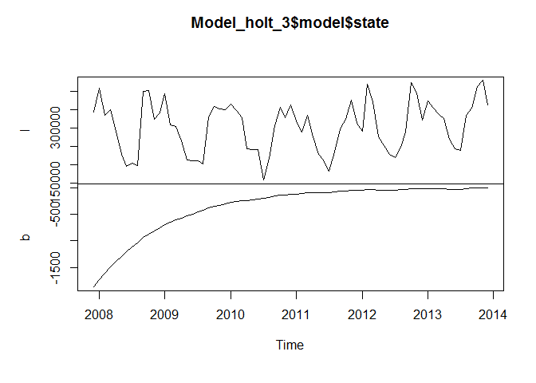

```r
plot(Model_holt_3$model$state)
```

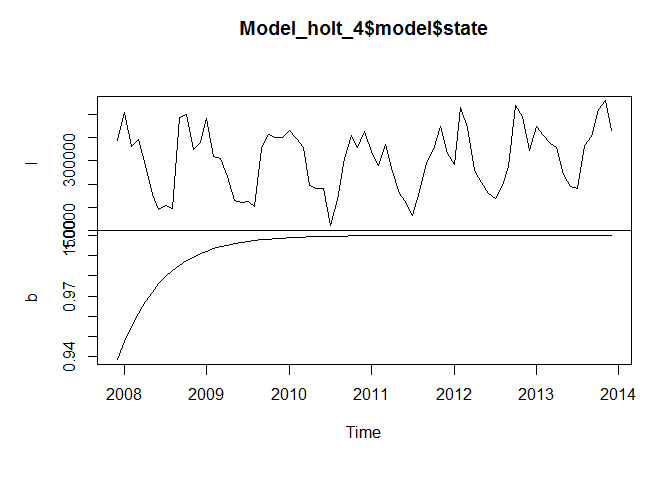

```r
plot(Model_holt_4$model$state)
```

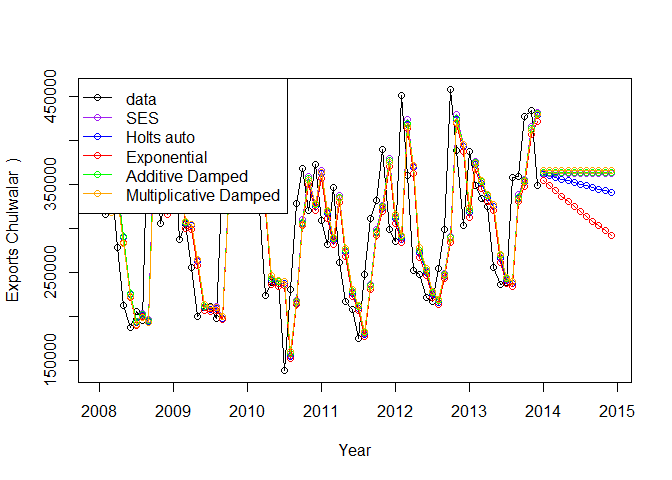

```r
plot(Model_holt_1, plot.conf=FALSE, ylab="Exports Chulwalar  )", xlab="Year", main="", fcol="white", type="o")
lines(fitted(Model_ses), col="purple", type="o")
lines(fitted(Model_holt_1), col="blue", type="o")
lines(fitted(Model_holt_2), col="red", type="o")
lines(fitted(Model_holt_3), col="green", type="o")
lines(fitted(Model_holt_4), col="orange", type="o")
lines(Model_ses$mean, col="purple", type="o")
lines(Model_holt_1$mean, col="blue", type="o")
lines(Model_holt_2$mean, col="red", type="o")
lines(Model_holt_3$mean, col="green", type="o")
lines(Model_holt_4$mean, col="orange", type="o")
legend("topleft",lty=1, col=c(1,"purple","blue","red","green","orange"), c("data", "SES","Holts auto", "Exponential", "Additive Damped", "Multiplicative Damped"),pch=1)
```

#### As these forecasts are not very convincing at the moment, there is no need

#### to export the data.

#### Model 3 - Holt - Winter’s seasonality model

#### This model expands the Holt’s model to futher include the seasonality aspect

#### There are 2 models under this, the additive model and multiplicative model

#### 3.1 Additive Model

```r
Model_hw_1 <- hw(BlueEtelAsIs ,seasonal="additive",h=12)
summary(Model_hw_1)
```

```
##
## Forecast method: Holt-Winters' additive method
##
## Model Information:
## Holt-Winters' additive method
##
## Call:
##  hw(x = BlueEtelAsIs, h = 12, seasonal = "additive")
##
##   Smoothing parameters:
##     alpha = 0.0147
##     beta  = 0.0147
##     gamma = 0.0001
##
##   Initial states:
##     l = 313008.9319
##     b = -1080.7413
##     s=36712.36 53999.56 89090.19 53986.79 -68669.93 -106522.5
##            -79256.58 -69589.39 -36619.22 32948.66 42663.88 51256.12
##
##   sigma:  37002.34
##
##      AIC     AICc      BIC
## 1854.618 1864.509 1891.045
##
## Error measures:
##                  ME     RMSE      MAE       MPE     MAPE      MASE
## Training set 4506.6 37002.34 29156.11 0.2573195 9.566305 0.7563733
##                    ACF1
## Training set -0.2436937
##
## Forecasts:
##          Point Forecast    Lo 80    Hi 80    Lo 95    Hi 95
## Jan 2014       408230.9 360810.5 455651.3 335707.6 480754.1
## Feb 2014       403323.5 355856.9 450790.1 330729.6 475917.5
## Mar 2014       397308.5 349759.8 444857.1 324589.1 470027.9
## Apr 2014       331434.9 283758.3 379111.5 258519.9 404349.9
## May 2014       302157.1 254297.0 350017.3 228961.3 375352.9
## Jun 2014       296184.0 248075.1 344292.9 222607.8 369760.3
## Jul 2014       272617.8 224185.9 321049.8 198547.6 346688.1
## Aug 2014       314172.6 265335.0 363010.2 239481.9 388863.3
## Sep 2014       440512.9 391179.0 489846.8 365063.2 515962.6
## Oct 2014       479314.7 429386.9 529242.5 402956.7 555672.7
## Nov 2014       447923.5 397298.0 498549.0 370498.4 525348.6
## Dec 2014       434324.6 382891.4 485757.7 355664.3 512984.8
```

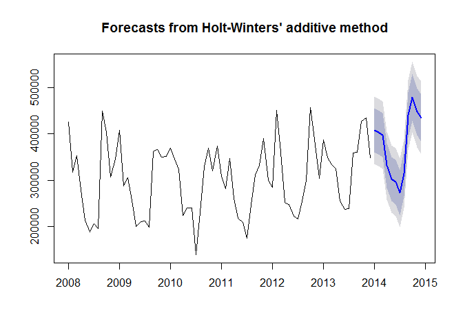

```r
plot(Model_hw_1)
```

#### 3.2 Multiplicative Model

```r
Model_hw_2 <- hw(BlueEtelAsIs ,seasonal="multiplicative",h=12)
summary(Model_hw_2)
```

```
##
## Forecast method: Holt-Winters' multiplicative method
##
## Model Information:
## Holt-Winters' multiplicative method
##
## Call:
##  hw(x = BlueEtelAsIs, h = 12, seasonal = "multiplicative")
##
##   Smoothing parameters:
##     alpha = 0.015
##     beta  = 0.015
##     gamma = 0.0001
##
##   Initial states:
##     l = 308752.254
##     b = -709.4998
##     s=1.1117 1.1911 1.2944 1.1664 0.8046 0.6596
##            0.6946 0.7435 0.8856 1.1223 1.1276 1.1986
##
##   sigma:  0.1218
##
##      AIC     AICc      BIC
## 1848.746 1858.637 1885.173
##
## Error measures:
##                    ME     RMSE      MAE       MPE     MAPE      MASE
## Training set 3807.777 36985.28 28863.82 0.0819902 9.553147 0.7487907
##                    ACF1
## Training set -0.2235846
##
## Forecasts:
##          Point Forecast    Lo 80    Hi 80    Lo 95    Hi 95
## Jan 2014       435410.6 367436.5 503384.7 331453.1 539368.1
## Feb 2014       414001.1 349340.6 478661.6 315111.4 512890.8
## Mar 2014       416470.7 351360.9 481580.5 316893.8 516047.5
## Apr 2014       332085.6 280080.2 384091.1 252550.2 411621.1
## May 2014       281716.0 237484.3 325947.7 214069.5 349362.5
## Jun 2014       265920.0 224016.7 307823.3 201834.4 330005.5
## Jul 2014       255076.9 214688.8 295465.0 193308.7 316845.1
## Aug 2014       314285.4 264218.9 364351.9 237715.2 390855.6
## Sep 2014       460190.3 386332.5 534048.1 347234.6 573146.1
## Oct 2014       515758.4 432244.0 599272.9 388034.2 643482.7
## Nov 2014       479241.3 400832.9 557649.7 359326.0 599156.6
## Dec 2014       451675.7 376898.3 526453.0 337313.6 566037.8
```

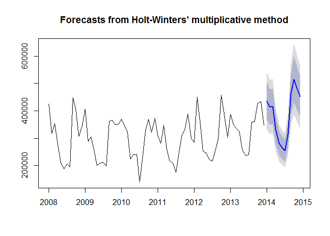

```r
plot(Model_hw_2)
```

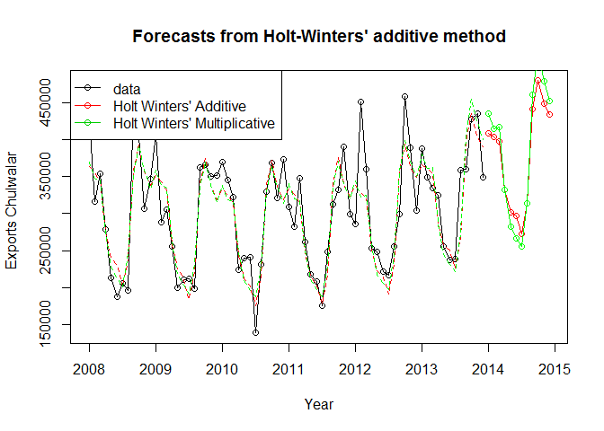

```r
plot(Model_hw_1, ylab="Exports Chulwalar  ", plot.conf=FALSE, type="o", fcol="white", xlab="Year")
lines(fitted(Model_hw_1), col="red", lty=2)
lines(fitted(Model_hw_2), col="green", lty=2)
lines(Model_hw_1$mean, type="o", col="red")
lines(Model_hw_2$mean, type="o", col="green")
legend("topleft",lty=1, pch=1, col=1:3, c("data","Holt Winters' Additive","Holt Winters' Multiplicative"))
```

```r
# In order to use the results later, they need to be converted into point forcasts.
Model_hw_1_df <-as.data.frame(Model_hw_1)
Model_hw_1_PointForecast <- ts(Model_hw_1_df$"Point Forecast", start=c(2014,1), end=c(2014,12), frequency=12)
Model_hw_1_PointForecast
```

```
##           Jan      Feb      Mar      Apr      May      Jun      Jul
## 2014 408230.9 403323.5 397308.5 331434.9 302157.1 296184.0 272617.8
##           Aug      Sep      Oct      Nov      Dec
## 2014 314172.6 440512.9 479314.7 447923.5 434324.6
```

```r
Model_hw_2_df <-as.data.frame(Model_hw_2)
Model_hw_2_PointForecast <- ts(Model_hw_2_df$"Point Forecast", start=c(2014,1), end=c(2014,12), frequency=12)
Model_hw_2_PointForecast
```

```
##           Jan      Feb      Mar      Apr      May      Jun      Jul
## 2014 435410.6 414001.1 416470.7 332085.6 281716.0 265920.0 255076.9
##           Aug      Sep      Oct      Nov      Dec
## 2014 314285.4 460190.3 515758.4 479241.3 451675.7
```

```r
# Output instruction for the data export of the results for further use in Excel.
#write.csv(Model_hw_1_PointForecast,file='Model_hw_1_PointForecast.csv')
#write.csv(Model_hw_2_PointForecast,file='Model_hw_2_PointForecast.csv')
```

### Results -

#### SES

#### AIC AICc BIC

#### 1920.425 1920.599 1924.978

#### Holt’s Linear Model

#### AIC AICc BIC

#### 1925.314 1925.911 1934.420

#### Holt’s method with exponential trend

#### AIC AICc BIC

#### 1946.718 1947.315 1955.824

#### Damped Holt’s Model

#### AIC AICc BIC

#### 1927.177 1928.086 1938.560

#### Damped Holt’s method with exponential trend

#### AIC AICc BIC

#### 1947.789 1948.698 1959.172

#### Holt-Winters’ additive model

#### AIC AICc BIC

#### 1854.618 1864.509 1891.045

#### Holt-Winters’ multiplicative model

#### AIC AICc BIC

#### 1848.746 1858.637 1885.173

#### Based on the AIC values, we see that Holt-Winters’ multiplicative model is the best fit for the determining the forecast

#### The forecast for Blue Etel based on this model is

```r
Model_hw_2_PointForecast
```

```
##           Jan      Feb      Mar      Apr      May      Jun      Jul
## 2014 435410.6 414001.1 416470.7 332085.6 281716.0 265920.0 255076.9
##           Aug      Sep      Oct      Nov      Dec
## 2014 314285.4 460190.3 515758.4 479241.3 451675.7
```